# project.Rmd

Corey May

3/20/2018

**Practical Machine Learning**

Below are the steps I took to complete the end of course project. This write-up is split into 3 sections data preparation/exploratory data analysis (EDA), modeling and results.

**Data Preparation and EDA**

The first step of the project was data preparation and EDA. I began by eliminating variables that had missing data, 100 out of 160 variables had missing values (NA’s) for 98% of the 19,622 records. These variables were removed from the analysis in both the training and test sets (see figure 1).

```r
## Read in and prepare data
pmltrain = read.csv("/Users/cmay/Documents/Training/pml-training.csv", stringsAsFactors=FALSE)
pmltest  = read.csv("/Users/cmay/Documents/Training/pml-testing.csv",  stringsAsFactors=FALSE)
  names(pmltrain)[names(pmltrain)=='X'] <- 'id'
  names(pmltest )[names(pmltest) =='X'] <- 'id'
  table(pmltrain$classe, exclude=FALSE)
```

```
##
##    A    B    C    D    E
## 5580 3797 3422 3216 3607
```

```r
## Get the number of NA records in a dataframes of columns
countnas <- function(z) {
  na_count <-sapply(z, function(y) sum(length(which(is.na(y) | y == ""))))
  na_count <- data.frame(na_count)
  na_count$pct <- round(na_count$na_count  / nrow(z),4)
  return(na_count)
}
```

Figure 1- excerpt of variables to be removed

```r
## Writeout table for report
head(countnas(pmltrain),20)
```

```
##                      na_count    pct
## id                          0 0.0000
## user_name                   0 0.0000
## raw_timestamp_part_1        0 0.0000
## raw_timestamp_part_2        0 0.0000
## cvtd_timestamp              0 0.0000
## new_window                  0 0.0000
## num_window                  0 0.0000
## roll_belt                   0 0.0000
## pitch_belt                  0 0.0000
## yaw_belt                    0 0.0000
## total_accel_belt            0 0.0000
## kurtosis_roll_belt      19216 0.9793
## kurtosis_picth_belt     19216 0.9793
## kurtosis_yaw_belt       19216 0.9793
## skewness_roll_belt      19216 0.9793
## skewness_roll_belt.1    19216 0.9793
## skewness_yaw_belt       19216 0.9793
## max_roll_belt           19216 0.9793
## max_picth_belt          19216 0.9793
## max_yaw_belt            19216 0.9793
```

Next, I explored predictors that were not associated with the outcome variable ‘classe’. I used a series of plotting techniques, boxplots, density plots, histograms, etc. to visualize the relationships (see figure 2). I determined that all the variables that began with “gyro” could be removed as most of the values for these predictors were near-zero or zero and would not be good classifiers for the outcome variable.

Finally, I investigated whether principal component analysis (PCA) could be used to reduce the number of predictors and/or identify predictors that were correlated. The results of this did not appear helpful so I did not use PCA (see Figure 3).

```r
## Remove vars with at least one NA, most have 19K NA's
## Set sample seed here.  This will be run 3 times by changing the seed to create different samples
## Could also build a function for all of this work if I want to
  ## 1) seed 41;
  ## 2) seed 92621;
  ## 3) seed 52800
set.seed(41)
pmltrain.clean <- pmltrain[ , apply(pmltrain, 2, function(x) {!any(is.na(x)) & !any( x == "") } )]
pmltest.clean  <- pmltest[ ,  apply(pmltest, 2, function(x) {!any(is.na(x)) & !any( x == "") } )]

## Remove character, id and timestamp variables from final test set
pmltest.clean  <- pmltest.clean[,-c(1:7)]

## Build cross-validation training and test sets
intrain  = createDataPartition(pmltrain.clean$classe, p=3/4)[[1]]
training = pmltrain.clean[ intrain, ]
testing  = pmltrain.clean[-intrain, ]

## Remove indicator, character and time variables from training data
training <- training[,-c(1:7)]

## Prepare 'clean' testing data set for trained models
testing.clean <- testing[ , apply(testing, 2, function(x) {!any(is.na(x)) & !any( x == "") } )]
testing.clean <- testing.clean[,-c(1:7)]
```

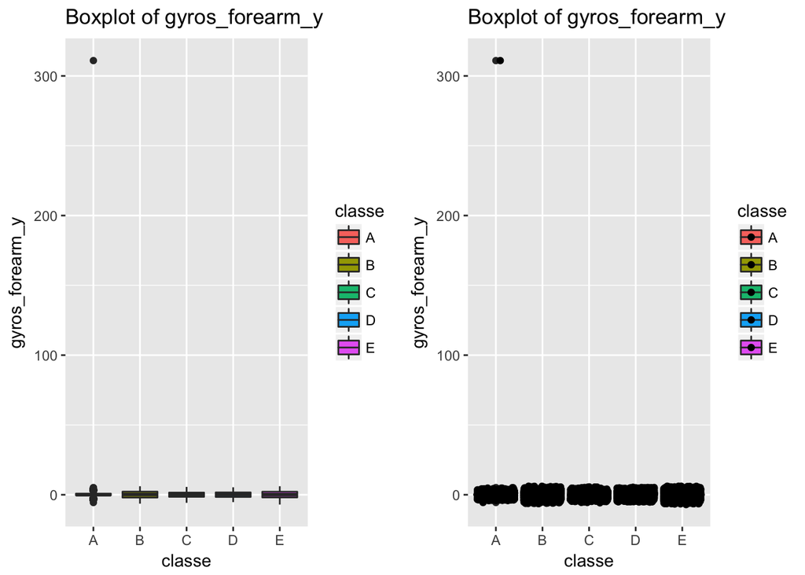

Figure 3- principal component plot

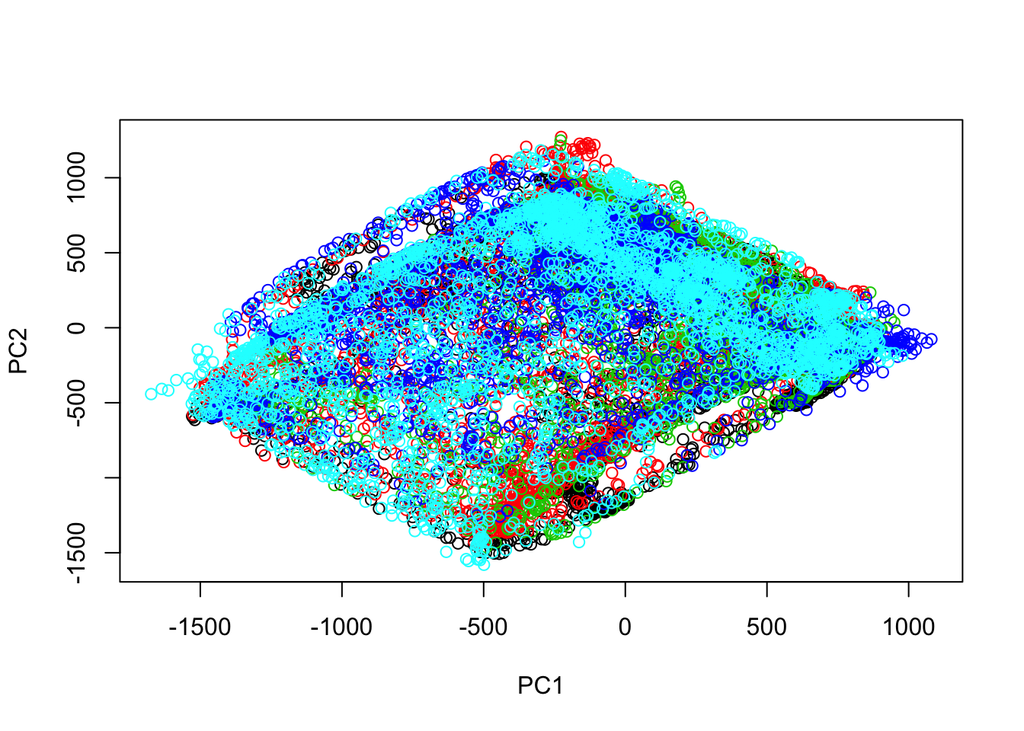

**Modeling**

For the exploratory data analysis the data was partitioned into training and test sets (75%/25% split). I continued on with this split creating three subsamples for 3-fold cross validation. One run of the cross validation is highlighted in this section but all three were run and the results summarized below. The training and test sets had 14,718 and 4,904 observations with 60 variables, respectively. After removing the predictors starting with “gyro” and seven additional character, timestamp and/or id variables I was left with 40 predictors to train/test on.

```r
#### Rpart- classification and regression tree
mod.rpart <- train(classe ~ ., data=training, method="rpart")
mod.rpart$finalModel
```

```
## n= 14718
##
## node), split, n, loss, yval, (yprob)
##       * denotes terminal node
##
##  1) root 14718 10533 A (0.28 0.19 0.17 0.16 0.18)
##    2) roll_belt< 129.5 13400  9266 A (0.31 0.21 0.19 0.18 0.11)
##      4) pitch_forearm< -33.95 1190     7 A (0.99 0.0059 0 0 0) *
##      5) pitch_forearm>=-33.95 12210  9259 A (0.24 0.23 0.21 0.2 0.12)
##       10) magnet_dumbbell_y< 439.5 10331  7438 A (0.28 0.18 0.24 0.19 0.1)
##         20) roll_forearm< 122.5 6395  3806 A (0.4 0.18 0.18 0.17 0.058) *
##         21) roll_forearm>=122.5 3936  2632 C (0.077 0.18 0.33 0.23 0.18) *
##       11) magnet_dumbbell_y>=439.5 1879   909 B (0.031 0.52 0.045 0.22 0.19) *
##    3) roll_belt>=129.5 1318    51 E (0.039 0 0 0 0.96) *
```

```r
## Get predictions and confusion(accuracy matrix) for rpart
pred.rpart <- predict(mod.rpart, testing)
confusionMatrix(testing$classe, pred.rpart)
```

```
## Confusion Matrix and Statistics
##
##           Reference
## Prediction    A    B    C    D    E
##          A 1243   23  106    0   23
##          B  389  316  244    0    0
##          C  408   23  424    0    0
##          D  350  159  295    0    0
##          E  118  109  242    0  432
##
## Overall Statistics
##
##                Accuracy : 0.4925
##                  95% CI : (0.4784, 0.5066)
##     No Information Rate : 0.5114
##     P-Value [Acc > NIR] : 0.9962
##
##                   Kappa : 0.3374
##  Mcnemar's Test P-Value : NA
##
## Statistics by Class:
##
##                      Class: A Class: B Class: C Class: D Class: E
## Sensitivity            0.4956  0.50159  0.32342       NA  0.94945
## Specificity            0.9366  0.85190  0.88004   0.8361  0.89458
## Pos Pred Value         0.8910  0.33298  0.49591       NA  0.47947
## Neg Pred Value         0.6395  0.92061  0.78093       NA  0.99425
## Prevalence             0.5114  0.12847  0.26733   0.0000  0.09278
## Detection Rate         0.2535  0.06444  0.08646   0.0000  0.08809
## Detection Prevalence   0.2845  0.19352  0.17435   0.1639  0.18373
## Balanced Accuracy      0.7161  0.67674  0.60173       NA  0.92202
```

[figure not shown]

```r
## Plot Classification and Regression Tree
  par(mar=c(1,4,1,4))
  plot(mod.rpart$finalModel, uniform=TRUE, main="Classification Tree", cex.main=0.75)
  text(mod.rpart$finalModel, use.n=TRUE, all=TRUE, cex=0.7,pos=1)
```

```r
#### RF- Random Forest
mod.rf <- train(classe ~ ., data=training2, method="rf")
mod.rf$finalModel
```

```
##
## Call:
##  randomForest(x = x, y = y, mtry = param$mtry)
##                Type of random forest: classification
##                      Number of trees: 500
## No. of variables tried at each split: 21
##
##         OOB estimate of  error rate: 0.74%
## Confusion matrix:
##      A    B    C    D    E class.error
## A 4179    3    2    0    1 0.001433692
## B   21 2811   15    1    0 0.012991573
## C    0   12 2546    9    0 0.008180756
## D    0    1   25 2385    1 0.011194030
## E    0    2    6   10 2688 0.006651885
```

```r
## Get predictions and confusion(accuracy matrix) for rf
pred.rf <- predict(mod.rf, testing2)
confusionMatrix(testing2$classe, pred.rf)
```

```
## Confusion Matrix and Statistics
##
##           Reference
## Prediction    A    B    C    D    E
##          A 1395    0    0    0    0
##          B   10  935    4    0    0
##          C    0    3  849    3    0
##          D    0    0    5  797    2
##          E    0    1    3    3  894
##
## Overall Statistics
##
##                Accuracy : 0.9931
##                  95% CI : (0.9903, 0.9952)
##     No Information Rate : 0.2865
##     P-Value [Acc > NIR] : < 2.2e-16
##
##                   Kappa : 0.9912
##  Mcnemar's Test P-Value : NA
##
## Statistics by Class:
##
##                      Class: A Class: B Class: C Class: D Class: E
## Sensitivity            0.9929   0.9957   0.9861   0.9925   0.9978
## Specificity            1.0000   0.9965   0.9985   0.9983   0.9983
## Pos Pred Value         1.0000   0.9852   0.9930   0.9913   0.9922
## Neg Pred Value         0.9972   0.9990   0.9970   0.9985   0.9995
## Prevalence             0.2865   0.1915   0.1756   0.1637   0.1827
## Detection Rate         0.2845   0.1907   0.1731   0.1625   0.1823
## Detection Prevalence   0.2845   0.1935   0.1743   0.1639   0.1837
## Balanced Accuracy      0.9964   0.9961   0.9923   0.9954   0.9980
```

```r
#### GBM- boosting with trees
mod.gbm <- train(classe ~ ., data=training2, method="gbm", verbose=FALSE)
mod.gbm$finalModel
```

```
## A gradient boosted model with multinomial loss function.
## 150 iterations were performed.
## There were 40 predictors of which 36 had non-zero influence.
```

```r
## get predictions and confusion(accuracy matrix) for gbm
pred.gbm <- predict(mod.gbm, testing2)
confusionMatrix(testing2$classe, pred.gbm)
```

```
## Confusion Matrix and Statistics
##
##           Reference
## Prediction    A    B    C    D    E
##          A 1366   19    7    2    1
##          B   27  886   33    0    3
##          C    0   30  817    7    1
##          D    0    8   19  775    2
##          E    2   18   11   14  856
##
## Overall Statistics
##
##                Accuracy : 0.9584
##                  95% CI : (0.9524, 0.9638)
##     No Information Rate : 0.2845
##     P-Value [Acc > NIR] : < 2.2e-16
##
##                   Kappa : 0.9474
##  Mcnemar's Test P-Value : 9.404e-08
##
## Statistics by Class:
##
##                      Class: A Class: B Class: C Class: D Class: E
## Sensitivity            0.9792   0.9220   0.9211   0.9712   0.9919
## Specificity            0.9917   0.9840   0.9905   0.9929   0.9889
## Pos Pred Value         0.9792   0.9336   0.9556   0.9639   0.9501
## Neg Pred Value         0.9917   0.9810   0.9827   0.9944   0.9983
## Prevalence             0.2845   0.1960   0.1809   0.1627   0.1760
## Detection Rate         0.2785   0.1807   0.1666   0.1580   0.1746
## Detection Prevalence   0.2845   0.1935   0.1743   0.1639   0.1837
## Balanced Accuracy      0.9855   0.9530   0.9558   0.9821   0.9904
```

```r
#### Ensemble Model
## Stack RPART, RF and GBM models
stacked.dat <- data.frame(pred.rpart, pred.rf, pred.gbm, classe=testing2$classe)
str(stacked.dat)
```

```
## 'data.frame':    4904 obs. of  4 variables:
##  $ pred.rpart: Factor w/ 5 levels "A","B","C","D",..: 1 1 1 1 1 1 1 1 1 1 ...
##  $ pred.rf   : Factor w/ 5 levels "A","B","C","D",..: 1 1 1 1 1 1 1 1 1 1 ...
##  $ pred.gbm  : Factor w/ 5 levels "A","B","C","D",..: 1 1 1 1 1 1 1 1 1 1 ...
##  $ classe    : Factor w/ 5 levels "A","B","C","D",..: 1 1 1 1 1 1 1 1 1 1 ...
```

```r
## Train the combined stacked predictors using random forests
mod.stack  <- train(classe ~., method="rf", data=stacked.dat)

## Get predictions and confusion(accuracy matrix) for stacked models
pred.stack <- predict(mod.stack, stacked.dat)
confusionMatrix(testing2$classe, pred.stack)
```

```
## Confusion Matrix and Statistics
##
##           Reference
## Prediction    A    B    C    D    E
##          A 1395    0    0    0    0
##          B   10  935    4    0    0
##          C    0    3  849    3    0
##          D    0    0    5  797    2
##          E    0    1    3    3  894
##
## Overall Statistics
##
##                Accuracy : 0.9931
##                  95% CI : (0.9903, 0.9952)
##     No Information Rate : 0.2865
##     P-Value [Acc > NIR] : < 2.2e-16
##
##                   Kappa : 0.9912
##  Mcnemar's Test P-Value : NA
##
## Statistics by Class:
##
##                      Class: A Class: B Class: C Class: D Class: E
## Sensitivity            0.9929   0.9957   0.9861   0.9925   0.9978
## Specificity            1.0000   0.9965   0.9985   0.9983   0.9983
## Pos Pred Value         1.0000   0.9852   0.9930   0.9913   0.9922
## Neg Pred Value         0.9972   0.9990   0.9970   0.9985   0.9995
## Prevalence             0.2865   0.1915   0.1756   0.1637   0.1827
## Detection Rate         0.2845   0.1907   0.1731   0.1625   0.1823
## Detection Prevalence   0.2845   0.1935   0.1743   0.1639   0.1837
## Balanced Accuracy      0.9964   0.9961   0.9923   0.9954   0.9980
```

**Results and predictions**

Below is the result table with my out of sample accuracy. The Random Forest and Boosting models performed much better than the Classification and Regression Tree model. The ensemble model was also very accurate. I used the RF model to make my final predictions. The predictions were the same using the RF model from any of the three samples. These predictions scored a 100% on the final prediction quiz.

Table of Out of Sample Accuracy

```r
readRDS(file="/Users/cmay/Documents/Training/finalresults.rds")
```

```
##       model.type Sample1 Sample2 Sample3 Average
## 1          RPART    49.3    49.9    49.4    49.5
## 2             RF    99.3    98.9    98.9    99.0
## 3            GBM    95.8    95.8    95.7    95.8
## 4 Ensemble Model    99.3    98.9    98.9    99.0
```

Final predictions on the provided 20 test cases,

```r
##### Final Predictions
## Make final predictions for end of project quiz using Random Forests as it had the best out of sample accuracy
final.prediction <- predict(mod.rf, pmltest.clean)
final.prediction
```

```
##  [1] B A B A A E D B A A B C B A E E A B B B
## Levels: A B C D E
```

```r
summary(final.prediction)
```

```
## A B C D E
## 7 8 1 1 3
```

**Predictions**

Sample 1-RF B A B A A E D B A A B C B A E E A B B B  
Sample 2-RF B A B A A E D B A A B C B A E E A B B B  
Sample 3-RF B A B A A E D B A A B C B A E E A B B B